# Predictive Analysis with Text

# About the Data

This dataset is based on a set of Amazon review of video games downloaded from Prof. Julian McAuley’s [website](http://jmcauley.ucsd.edu/data/amazon/). The original json dataset was parsed into a dataframe and cleaned. Since this dataset is very large, I have only included data from Aug 2013 to July 2014 which gives us a year of data to work with. Also we are only using data on three fields, id, review and review rating. Finally, three blank reviews were dropped from the data. The data we are going to use includes the following fields:

- id: A unique identifier for each review
- review: Text of review posted on Amazon
- review_rating: Each review on Amazon is rated by others using a five-star scale (presumably based on helpfulness of review)

# Read Data

You must read the data before trying to run the code on your own machine. To read data use the following code after setting your working directory.

```r
videogame = read.csv('video_game_reviews.csv',stringsAsFactors = F)
```

# Prepare Data

### Clean and Tokenize

There are many ways to quantify text. Here, we will use the bag of words approach where we first clean the data and then extract individual words, a process known as tokenization. Specifically, we will create a corpus, clean the text, and generate a matrix derived from term frequencies.

1. Create a corpus from the variable ‘review’
2. Use tm_map to
1. transform text to lower case,
2. remove punctuation,
3. remove English stopwords using the following dictionary tm::stopwords(’english)
4. remove urls
5. remove whitespace
3. Create a dictionary
4. Use tm_map to stem words
5. Create a DocumentTermMatrix

You can learn more about cleaning functions in tm in [this vignette](https://cran.r-project.org/web/packages/tm/vignettes/tm.pdf) We are going to make use of library(tm) and a few other text analysis libraries, but you based on analysis goal, you may want to consider [other available libraries](https://cran.r-project.org/web/views/NaturalLanguageProcessing.html).

### Create a corpus

```r
library(tm)
corpus = Corpus(VectorSource(videogame$review))
```

Examine Review 617 (now a document)

```r
corpus[[617]]
```

```
## <<PlainTextDocument>>
## Metadata:  7
## Content:  chars: 717
```

Examine content of Review 617

```r
corpus[[617]][1]
```

```
## $content
## [1] "Like scottrocket3 said, you're out of your damn mind if you buy this for $200.  This is the best Mario game that ever came out.  The other is Super Mario World for Super Nintendo, also available for Nintendo DS.  I can't say enough about this great game!!  I LOVED the Super Mario Brothers Su…
```

### Clean text

- convert to lower case
- remove urls
- remove punctuation
- remove stopwords
- remove whitespace

Convert to lower case

```r
corpus = tm_map(corpus,FUN = content_transformer(tolower))
corpus[[617]][1]
```

```
## $content
## [1] "like scottrocket3 said, you're out of your damn mind if you buy this for $200.  this is the best mario game that ever came out.  the other is super mario world for super nintendo, also available for nintendo ds.  i can't say enough about this great game!!  i loved the super mario brothers su…
```

Remove urls  
There are a few urls within the reviews. Use regular expressions to specify the pattern of a url. Replace urls with a blank.  
For an introduction to regular expressions, see [Chapter on Strings in R for Data Science](https://r4ds.had.co.nz/strings.html) or [Regular Expressions Vignette on CRAN](https://cran.r-project.org/web/packages/stringr/vignettes/regular-expressions.html). For a quick search, use a [RegEx Cheatsheet](https://www.rstudio.com/wp-content/uploads/2016/09/RegExCheatsheet.pdf)

Lets examine Review 4607 (instead of 617) since it has a url. Review 617 does not have a url to remove, but don’t worry we will get back to 617 after this illustration.

```r
corpus[[4607]][1]
```

```
## $content
## [1] "since ps2's and ps3's use the exact same composite or component cable, i figured this would work........ guess i was wrong. for more info read this review, not typing it all again:http://www.amazon.com/review/r11mcq8esc5a3j/ref=cm_cr_rev_detup_redir?_encoding=utf8&asin;=b0017o5k0i&cdforum;=f…
```

Match pattern and replace url with blank space.

```r
corpus = tm_map(corpus,
                FUN = content_transformer(function(x)gsub(pattern = 'http[[:alnum:][:punct:]]*',
                                                                replacement = ' ',x = x)))
corpus[[4607]][1]
```

```
## $content
## [1] "since ps2's and ps3's use the exact same composite or component cable, i figured this would work........ guess i was wrong. for more info read this review, not typing it all again:  lol ok changing my review...... maybe the red video cord wasn't plugged in all the way or some weird crap, cau…
```

Remove punctuation

```r
corpus = tm_map(corpus,FUN = removePunctuation)
corpus[[617]][1]
```

```
## $content
## [1] "like scottrocket3 said youre out of your damn mind if you buy this for 200  this is the best mario game that ever came out  the other is super mario world for super nintendo also available for nintendo ds  i cant say enough about this great game  i loved the super mario brothers super show f…
```

Remove stopwords

```r
corpus = tm_map(corpus,FUN = removeWords,c(stopwords('english')))
corpus[[617]][1]
```

```
## $content
## [1] "like scottrocket3 said youre    damn mind   buy   200     best mario game  ever came      super mario world  super nintendo also available  nintendo ds   cant say enough   great game   loved  super mario brothers super show featuring wrestling great captain lou albano  unfortunately passed a…
```

Strip whitespace

```r
corpus = tm_map(corpus,FUN = stripWhitespace)
corpus[[617]][1]
```

```
## $content
## [1] "like scottrocket3 said youre damn mind buy 200 best mario game ever came super mario world super nintendo also available nintendo ds cant say enough great game loved super mario brothers super show featuring wrestling great captain lou albano unfortunately passed away recently christian will…
```

### Create a dictionary

Stemming chops off the end of words but the manner in which it does so may render the words meaningless. Here we are creating a dictionary of all words. Once, similar words have been grouped together, the part that was chopped off will be reintegrated using the dictionary created here.

```r
dict = findFreqTerms(DocumentTermMatrix(Corpus(VectorSource(videogame$review))),
                     lowfreq = 0)
dict_corpus = Corpus(VectorSource(dict))
```

### Stem document

```r
corpus = tm_map(corpus,FUN = stemDocument)
corpus[[617]][1]
```

```
## $content
## [1] "like scottrocket3 said your damn mind buy 200 best mario game ever came super mario world super nintendo also avail nintendo ds cant say enough great game love super mario brother super show featur wrestl great captain lou albano unfortun pass away recent christian will see dont know danni w…
```

### Create a document term matrix (tokenize)

Note, here we are going with the default arguments which include using Term Frequency weighting for each term.

```r
dtm = DocumentTermMatrix(corpus)
dtm
```

```
## <<DocumentTermMatrix (documents: 26652, terms: 65864)>>
## Non-/sparse entries: 1235636/1754171692
## Sparsity           : 100%
## Maximal term length: 115
## Weighting          : term frequency (tf)
```

Each review is represented as a document in the document term matrix. Let us see how many times the word “game” appears in this review.

```r
inspect(dtm[617,])
```

```
## <<DocumentTermMatrix (documents: 1, terms: 65864)>>
## Non-/sparse entries: 60/65804
## Sparsity           : 100%
## Maximal term length: 115
## Weighting          : term frequency (tf)
## Sample             :
##      Terms
## Docs  game good got great mario nintendo said spend super vitamin
##   617    2    1   1     2     4        2    1     2     4       2
```

```r
inspect(dtm[617,'game'])
```

```
## <<DocumentTermMatrix (documents: 1, terms: 1)>>
## Non-/sparse entries: 1/0
## Sparsity           : 0%
## Maximal term length: 4
## Weighting          : term frequency (tf)
## Sample             :
##      Terms
## Docs  game
##   617    2
```

The document term matrix contains a column for each term generated from tokenizing the corpus.

```r
dim(dtm)
```

```
## [1] 26652 65864
```

Inspect terms 24001 to 24010 for reviews 611 to 620. This sparsity, few 1s and mostly 0s is the norm, not the exception.

```r
inspect(dtm[611:620,24001:24010])
```

```
## <<DocumentTermMatrix (documents: 10, terms: 10)>>
## Non-/sparse entries: 0/100
## Sparsity           : 100%
## Maximal term length: 13
## Weighting          : term frequency (tf)
## Sample             :
##      Terms
## Docs  venezuelan veteranlevel dogthorough friendsi 2015after bc2bf3bf4 cod1uo
##   611          0            0           0        0         0         0      0
##   612          0            0           0        0         0         0      0
##   613          0            0           0        0         0         0      0
##   614          0            0           0        0         0         0      0
##   615          0            0           0        0         0         0      0
##   616          0            0           0        0         0         0      0
##   617          0            0           0        0         0         0      0
##   618          0            0           0        0         0         0      0
##   619          0            0           0        0         0         0      0
##   620          0            0           0        0         0         0      0
##      Terms
## Docs  disclaimers1 out2 performanceit
##   611            0    0             0
##   612            0    0             0
##   613            0    0             0
##   614            0    0             0
##   615            0    0             0
##   616            0    0             0
##   617            0    0             0
##   618            0    0             0
##   619            0    0             0
##   620            0    0             0
```

### Remove Sparse Terms

The document term matrix contains a very large number of tokens. Frequently with text analysis one is faced with the curse of dimensionality where there are more variables than observations. A simple way to address this is to remove infrequently occurring terms. Here we will remove terms that appear in fewer than 5% of the reviews. In other words, we will retain all terms that appear in 5% or more reviews. Thereafter we convert the document-term-matrix to a data frame and address any problems with column names as our column names will now be the tokens (i.e., words in the texts).

```r
xdtm = removeSparseTerms(dtm,sparse = 0.95)
xdtm
```

```
## <<DocumentTermMatrix (documents: 26652, terms: 158)>>
## Non-/sparse entries: 447491/3763525
## Sparsity           : 89%
## Maximal term length: 9
## Weighting          : term frequency (tf)
```

### Complete Stems

We are going to use the dictionary created earlier to complete the stems. This should make the terms more meaningful. Since the terms will now serve as column names for a dataframe, we need to ensure the terms comply with variable naming conventions in R.

```r
xdtm = as.data.frame(as.matrix(xdtm))
colnames(xdtm) = stemCompletion(x = colnames(xdtm),
                                dictionary = dict_corpus,
                                type='prevalent')
colnames(xdtm) = make.names(colnames(xdtm))
```

### Browse tokens

Next, we evaluate the frequency of the tokens as these frequencies will be used to weight the tokens. A word that occurs more frequently gets weighted more than one that appears less frequently.

```r
sort(colSums(xdtm),decreasing = T)
```

```
##           game           play           like            one            get
##          69555          22510          17771          15323          14463
##            can           just           time          great           will
##          14460          13184          10937          10333           9745
##            use           good       reallisc            fun        control
##           9711           9327           9304           8405           8267
##           much           make           love           dont           even
##           7424           7352           6791           6533           6447
##           look           also         storie          first           well
##           6427           6396           6315           6118           6097
##           work            new      character          thing           want
##           5857           5844           5807           5737           5514
##          still        graphic            lot           feel         better
##           5413           5350           5299           5161           5000
##            way            buy          level            say           xbox
##           4904           4786           4340           4329           4254
##           take           best            now          enjoy           need
##           4251           4219           4160           4083           4021
##          mania            tri         little            got         system
##           3961           3888           3885           3882           3866
##         player       prettier           back          think         differ
##           3768           3719           3709           3624           3608
##           come            see         people           find           give
##           3581           3549           3403           3388           3349
##            ive       gameplay           know           hour          start
##           3306           3302           3261           3135           3110
##           year         around         though      recommend         enemie
##           3048           3029           3028           3024           3017
##            fan           cant        version           seem         serial
##           3006           3004           2959           2958           2955
##         actual              X          since          never          world
##           2905           2900           2899           2863           2863
##         bought            wii           your            two            end
##           2837           2834           2783           2769           2762
##         review            bit            far           nice          right
##           2762           2743           2739           2723           2684
##          price          didnt            ps4        consola         origin
##           2680           2673           2653           2648           2647
##            set           hard            bad            run           mode
##           2644           2642           2616           2607           2597
```

[output cut: 9 more lines]

```
##           2218           2209           2194           2182           2154
##           amaz        another     experiance         enough          alway
##           2146           2146           2145           2090           2073
##            put           last        without            may           isnt
##           2064           2056           2035           2033           2014
## everythime.the           turn         expect          chang           quit
##           2001           1985           1983           1921           1906
##        awesome          issue           sure      challenge            big
##           1905           1889           1879           1873           1858
##       interest       definite         friend           help        perfect
##           1838           1824           1817           1775           1762
##         person         nother           able            let          next.
##           1742           1721           1681           1678           1637
##          money           came         overal
##           1577           1553           1533
```

### Document Term Matrix - tfidf

Now, we are going to consider another document term matrix, this time using Term Frequency - Inverse Document Frequency Weighting. Since the code is similar to the previous (term frequency) document term matrix, we will run the code in a single block.

```r
dtm_tfidf = DocumentTermMatrix(x=corpus,
                               control = list(weighting=function(x) weightTfIdf(x,normalize=F)))
xdtm_tfidf = removeSparseTerms(dtm_tfidf,sparse = 0.95)
xdtm_tfidf = as.data.frame(as.matrix(xdtm_tfidf))
colnames(xdtm_tfidf) = stemCompletion(x = colnames(xdtm_tfidf),
                                      dictionary = dict_corpus,
                                      type='prevalent')
colnames(xdtm_tfidf) = make.names(colnames(xdtm_tfidf))
sort(colSums(xdtm_tfidf),decreasing = T)
```

```
##           game            can           play           like            one
##      32408.595      28486.212      27180.275      27026.206      25401.440
##            get           just           will           time            use
##      25055.553      24011.027      22689.043      22586.054      22509.923
##        control       reallisc          great           good           make
##      21846.471      20560.469      18995.677      18839.042      18510.135
##      character            fun           much         storie           also
##      18383.272      18315.583      17884.857      17638.984      17604.953
##           even           look            new           dont          first
##      17139.911      17049.470      16930.176      16756.917      16491.865
##          thing           well           love          level           feel
##      16150.323      15964.853      15779.984      15678.275      15580.861
##           work           xbox           want          still            lot
##      15553.347      15170.814      15167.202      15141.902      15064.049
##            way         better        graphic         player         system
##      14551.377      14233.492      14214.303      13896.142      13742.668
##           take            buy            say         enemie          mania
##      13492.634      13382.580      13182.171      13028.166      12950.150
##            now           best           need            tri          enjoy
##      12879.417      12705.610      12619.037      12523.893      12491.747
##         little       prettier            wii           back         differ
##      12349.966      12288.623      12240.987      12208.191      12172.823
##         people            see            got           find          think
##      12019.502      11983.733      11911.943      11812.002      11758.341
##           come            ive        version       gameplay          world
##      11655.700      11518.099      11516.984      11298.669      11257.655
##           give            ps4           know          start           hour
##      11224.406      11164.091      11103.835      11023.735      10977.737
##           mode           your         serial         button         around
##      10975.500      10911.020      10883.444      10874.663      10765.415
##           seem        consola         though           year         actual
##      10662.355      10653.847      10625.394      10617.382      10527.155
##            fan           cant              X          since         review
##      10516.816      10451.400      10426.640      10364.655      10339.280
##         origin            end            ps3            set            two
##      10330.380      10327.284      10293.384      10273.982      10256.573
##          sound          never            run            bit            far
##      10250.747      10166.340      10142.746      10100.728       9923.776
##           nice          right          didnt      recommend            bad
##       9884.010       9805.912       9798.637       9711.899       9706.496
```

[output cut: 9 more lines]

```
##       8798.744       8700.830       8687.266       8681.926       8590.750
##            may        another           amaz           turn           high
##       8445.281       8429.473       8399.559       8393.077       8325.462
##         enough           last           isnt          alway            put
##       8325.355       8301.118       8255.904       8206.602       8174.450
##          issue        without      challenge          chang everythime.the
##       8112.666       8090.627       8055.917       8038.015       8007.034
##           quit         expect       interest        awesome            big
##       7982.764       7964.385       7701.594       7699.934       7672.158
##           help         friend           sure       definite         person
##       7606.157       7556.766       7556.580       7488.918       7410.189
##        perfect         nother            let           able          next.
##       7259.113       7240.420       7197.590       7187.437       7065.446
##          money         overal           came
##       6803.082       6611.618       6604.610
```

### Document Term Matrix: Term Frequency vs. Term Frequency Inverse Document Frequency

```r
xdtm[611:620,41:50]
```

|  | complete | consola | control | end | even | ever | fan | gameplay | give | graphic |
| --- | --- | --- | --- | --- | --- | --- | --- | --- | --- | --- |
| 611 | 0 | 0 | 0 | 0 | 0 | 0 | 0 | 0 | 1 | 0 |
| 612 | 0 | 0 | 1 | 0 | 1 | 0 | 0 | 0 | 0 | 0 |
| 613 | 0 | 0 | 0 | 0 | 0 | 0 | 0 | 0 | 0 | 0 |
| 614 | 0 | 0 | 0 | 0 | 0 | 0 | 0 | 0 | 0 | 0 |
| 615 | 0 | 0 | 0 | 0 | 0 | 0 | 0 | 0 | 0 | 0 |
| 616 | 0 | 0 | 0 | 0 | 0 | 0 | 0 | 0 | 0 | 0 |
| 617 | 0 | 0 | 0 | 0 | 0 | 1 | 0 | 0 | 0 | 0 |
| 618 | 0 | 0 | 2 | 0 | 0 | 0 | 0 | 0 | 2 | 2 |
| 619 | 0 | 0 | 0 | 0 | 1 | 0 | 1 | 0 | 0 | 0 |
| 620 | 0 | 0 | 0 | 0 | 0 | 0 | 0 | 0 | 0 | 0 |

```r
xdtm_tfidf[611:620,41:50]
```

|  | complete | consola | control | end | even | ever | fan | gameplay | give | graphic |
| --- | --- | --- | --- | --- | --- | --- | --- | --- | --- | --- |
| 611 | 0 | 0 | 0.000000 | 0 | 0.000000 | 0.000000 | 0.000000 | 0 | 3.351569 | 0.000000 |
| 612 | 0 | 0 | 2.642612 | 0 | 2.658587 | 0.000000 | 0.000000 | 0 | 0.000000 | 0.000000 |
| 613 | 0 | 0 | 0.000000 | 0 | 0.000000 | 0.000000 | 0.000000 | 0 | 0.000000 | 0.000000 |
| 614 | 0 | 0 | 0.000000 | 0 | 0.000000 | 0.000000 | 0.000000 | 0 | 0.000000 | 0.000000 |
| 615 | 0 | 0 | 0.000000 | 0 | 0.000000 | 0.000000 | 0.000000 | 0 | 0.000000 | 0.000000 |
| 616 | 0 | 0 | 0.000000 | 0 | 0.000000 | 0.000000 | 0.000000 | 0 | 0.000000 | 0.000000 |
| 617 | 0 | 0 | 0.000000 | 0 | 0.000000 | 3.776402 | 0.000000 | 0 | 0.000000 | 0.000000 |
| 618 | 0 | 0 | 5.285223 | 0 | 0.000000 | 0.000000 | 0.000000 | 0 | 6.703139 | 5.313758 |
| 619 | 0 | 0 | 0.000000 | 0 | 2.658587 | 0.000000 | 3.498608 | 0 | 0.000000 | 0.000000 |
| 620 | 0 | 0 | 0.000000 | 0 | 0.000000 | 0.000000 | 0.000000 | 0 | 0.000000 | 0.000000 |

The following horizontal bar chart contrasts the weights of term frequency and term frequency inverse document frequency weighting for the top 20 terms. Most noteworthy is the heavy weighting of the term “game”. Term Frequency assigns it a heavy weight because “game” is the most frequently occuring term. On the other hand, the word “game” appears in most of the reviews thus has little diagnostic value. Accordingly, Term Frequency - Inverse Document Frequency assigns “game” a much lower weight.

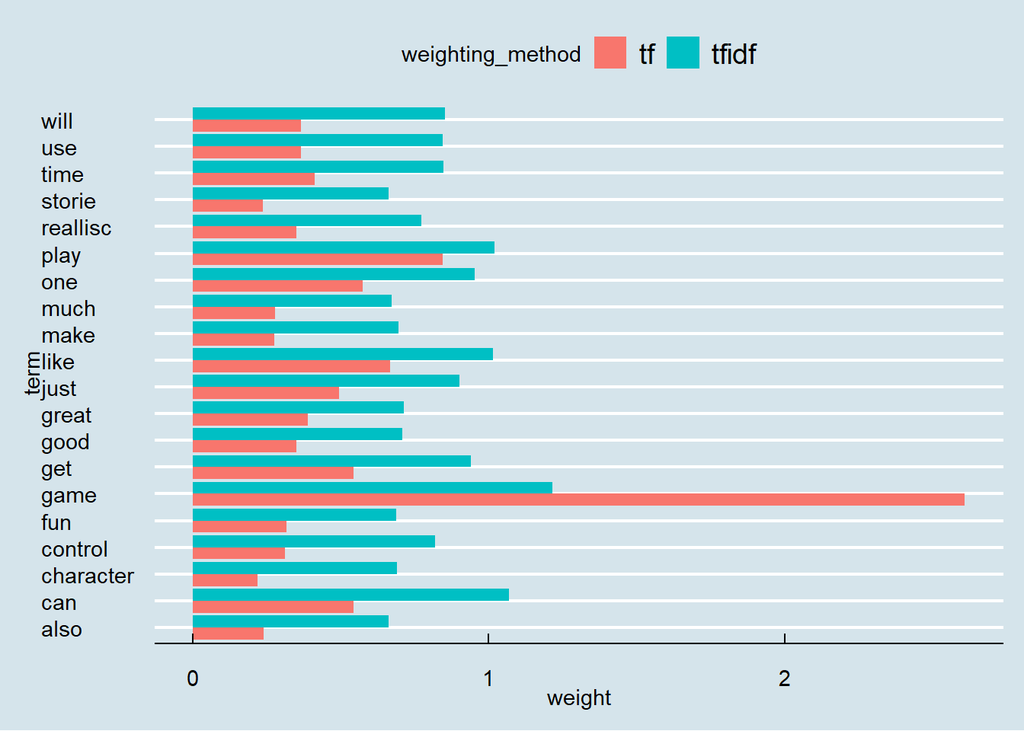

```r
library(tidyr); library(dplyr); library(ggplot2); library(ggthemes)
data.frame(term = colnames(xdtm),tf = colMeans(xdtm), tfidf = colMeans(xdtm_tfidf))%>%
  arrange(desc(tf))%>%
  top_n(20)%>%
  gather(key=weighting_method,value=weight,2:3)%>%
  ggplot(aes(x=term,y=weight,fill=weighting_method))+
  geom_col(position='dodge')+
  coord_flip()+
  theme_economist()
```

Add review_rating back to dataframe of features

```r
videogame_data = cbind(review_rating = videogame$review_rating,xdtm)
videogame_data_tfidf = cbind(review_rating = videogame$review_rating,xdtm_tfidf)
```

# Predictive Models (using TF features)

Split Data (TF)

```r
set.seed(617)
split = sample(1:nrow(videogame_data),size = 0.7*nrow(videogame_data))
train = videogame_data[split,]
test = videogame_data[-split,]
```

## CART

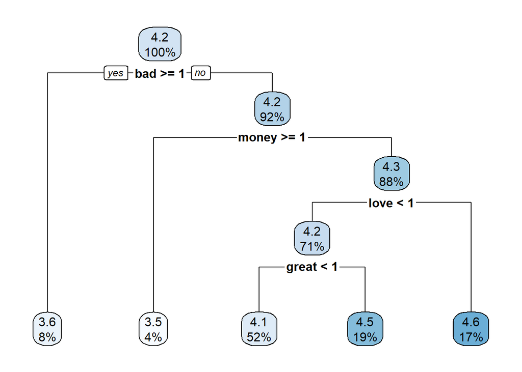

```r
library(rpart); library(rpart.plot)
set.seed(100)
tree = rpart(review_rating~.,train)
rpart.plot(tree)
```

Predictions

```r
pred_tree = predict(tree,newdata=test)
rmse_tree = sqrt(mean((pred_tree - test$review_rating)^2)); rmse_tree
```

```
## [1] 1.139024
```

## Regression

```r
reg = lm(review_rating~.,train)
summary(reg)
```

```
##
## Call:
## lm(formula = review_rating ~ ., data = train)
##
## Residuals:
##     Min      1Q  Median      3Q     Max
## -4.6334 -0.4454  0.4052  0.7585  4.3795
##
## Coefficients:
##                  Estimate Std. Error t value Pr(>|t|)
## (Intercept)     4.1324618  0.0118230 349.527  < 2e-16 ***
## can             0.0661146  0.0085388   7.743 1.02e-14 ***
## game           -0.0242193  0.0038849  -6.234 4.64e-10 ***
## good            0.0518814  0.0124763   4.158 3.22e-05 ***
## got            -0.0073809  0.0197083  -0.375 0.708031
## nother         -0.2601205  0.0291932  -8.910  < 2e-16 ***
## one             0.0261983  0.0096845   2.705 0.006833 **
## bad            -0.2871157  0.0222442 -12.907  < 2e-16 ***
## didnt          -0.0975079  0.0232077  -4.202 2.66e-05 ***
## dont           -0.0865969  0.0153148  -5.654 1.59e-08 ***
## everythime.the  0.0803620  0.0279493   2.875 0.004041 **
## first          -0.0022145  0.0143521  -0.154 0.877375
## get            -0.0148639  0.0096065  -1.547 0.121814
## great           0.1906091  0.0116348  16.383  < 2e-16 ***
## just           -0.0987659  0.0102531  -9.633  < 2e-16 ***
## like            0.0021591  0.0087370   0.247 0.804817
## never          -0.0334898  0.0230893  -1.450 0.146951
## say             0.0598797  0.0182090   3.288 0.001009 **
## since           0.0078862  0.0217788   0.362 0.717278
## somethimg      -0.1060703  0.0260422  -4.073 4.66e-05 ***
## still           0.0102752  0.0158867   0.647 0.517783
## sure            0.0097272  0.0297732   0.327 0.743891
## work           -0.0514593  0.0149102  -3.451 0.000559 ***
## able           -0.0602734  0.0295040  -2.043 0.041077 *
## bought          0.0168828  0.0231003   0.731 0.464882
## problem        -0.0357036  0.0239367  -1.492 0.135825
## love            0.2241882  0.0141998  15.788  < 2e-16 ***
## need           -0.0047800  0.0187138  -0.255 0.798396
## perfect         0.2610577  0.0286193   9.122  < 2e-16 ***
## reallisc        0.0150578  0.0117886   1.277 0.201506
```

[output cut: 120 more lines]

```
## chang          -0.0018339  0.0267919  -0.068 0.945428
## ps3             0.0483445  0.0174926   2.764 0.005720 **
## put            -0.0210837  0.0266018  -0.793 0.428042
## review         -0.0044587  0.0197148  -0.226 0.821081
## part            0.0193071  0.0249176   0.775 0.438446
## ps4            -0.0293490  0.0157135  -1.868 0.061812 .
## doesnt         -0.1174874  0.0248685  -4.724 2.33e-06 ***
## money          -0.4659074  0.0308812 -15.087  < 2e-16 ***
## xbox           -0.0017449  0.0124898  -0.140 0.888893
## ---
## Signif. codes:  0 '***' 0.001 '**' 0.01 '*' 0.05 '.' 0.1 ' ' 1
##
## Residual standard error: 1.094 on 18497 degrees of freedom
## Multiple R-squared:  0.1628, Adjusted R-squared:  0.1557
## F-statistic: 22.77 on 158 and 18497 DF,  p-value: < 2.2e-16
```

Predictions

```r
pred_reg = predict(reg, newdata=test)
rmse_reg = sqrt(mean((pred_reg-test$review_rating)^2)); rmse_reg
```

```
## [1] 1.093325
```

# Predictive Models (using TF-IDF features)

Split Data (TF-IDF)

```r
set.seed(617)
split = sample(1:nrow(videogame_data_tfidf),size = 0.7*nrow(videogame_data_tfidf))
train = videogame_data_tfidf[split,]
test = videogame_data_tfidf[-split,]
```

## CART

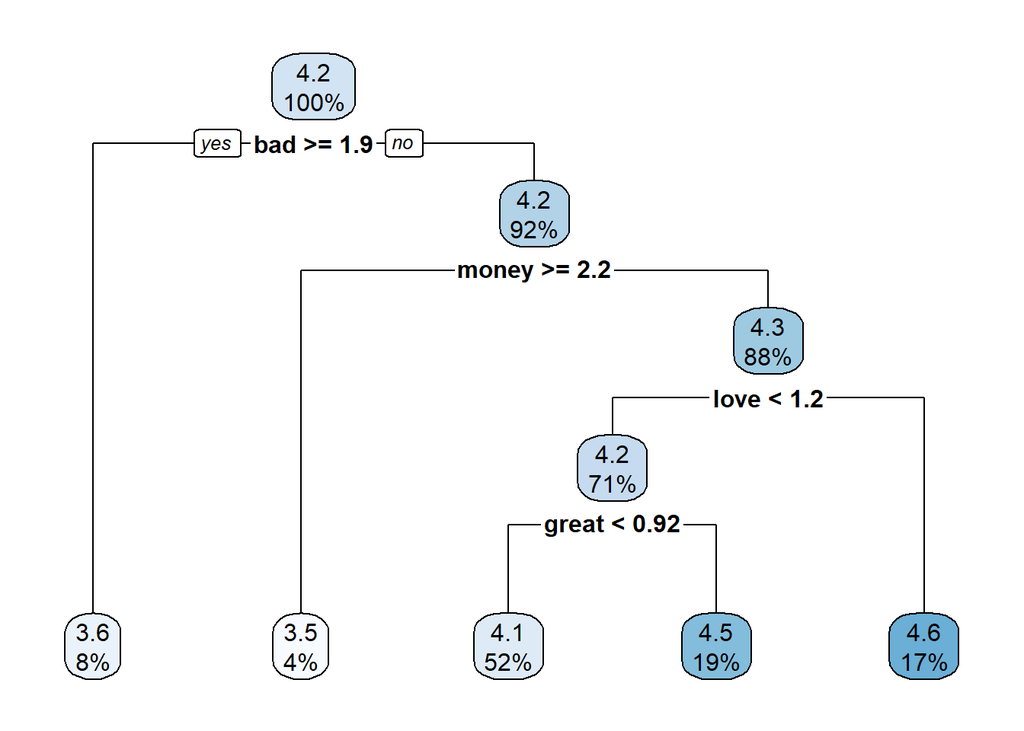

```r
library(rpart); library(rpart.plot)
set.seed(100)
tree = rpart(review_rating~.,train)
rpart.plot(tree)
```

Predictions

```r
pred_tree = predict(tree,newdata=test)
rmse_tree = sqrt(mean((pred_tree - test$review_rating)^2)); rmse_tree
```

```
## [1] 1.139024
```

## Regression

```r
reg = lm(review_rating~.,train)
summary(reg)
```

```
##
## Call:
## lm(formula = review_rating ~ ., data = train)
##
## Residuals:
##     Min      1Q  Median      3Q     Max
## -4.6334 -0.4454  0.4052  0.7585  4.3795
##
## Coefficients:
##                  Estimate Std. Error t value Pr(>|t|)
## (Intercept)     4.1324618  0.0118230 349.527  < 2e-16 ***
## can             0.0335607  0.0043344   7.743 1.02e-14 ***
## game           -0.0519793  0.0083378  -6.234 4.64e-10 ***
## good            0.0256859  0.0061769   4.158 3.22e-05 ***
## got            -0.0024054  0.0064228  -0.375 0.708031
## nother         -0.0618289  0.0069390  -8.910  < 2e-16 ***
## one             0.0158037  0.0058420   2.705 0.006833 **
## bad            -0.0773806  0.0059950 -12.907  < 2e-16 ***
## didnt          -0.0265995  0.0063309  -4.202 2.66e-05 ***
## dont           -0.0337614  0.0059708  -5.654 1.59e-08 ***
## everythime.the  0.0200829  0.0069847   2.875 0.004041 **
## first          -0.0008215  0.0053242  -0.154 0.877375
## get            -0.0085800  0.0055452  -1.547 0.121814
## great           0.1036848  0.0063289  16.383  < 2e-16 ***
## just           -0.0542305  0.0056298  -9.633  < 2e-16 ***
## like            0.0014197  0.0057450   0.247 0.804817
## never          -0.0094312  0.0065023  -1.450 0.146951
## say             0.0196644  0.0059798   3.288 0.001009 **
## since           0.0022058  0.0060915   0.362 0.717278
## somethimg      -0.0275548  0.0067652  -4.073 4.66e-05 ***
## still           0.0036732  0.0056793   0.647 0.517783
## sure            0.0024187  0.0074033   0.327 0.743891
## work           -0.0193783  0.0056148  -3.451 0.000559 ***
## able           -0.0140968  0.0069004  -2.043 0.041077 *
## bought          0.0049515  0.0067750   0.731 0.464882
## problem        -0.0090226  0.0060490  -1.492 0.135825
## love            0.0964806  0.0061109  15.788  < 2e-16 ***
## need           -0.0015231  0.0059631  -0.255 0.798396
## perfect         0.0633664  0.0069468   9.122  < 2e-16 ***
## reallisc        0.0068139  0.0053346   1.277 0.201506
```

[output cut: 120 more lines]

```
## chang          -0.0004383  0.0064030  -0.068 0.945428
## ps3             0.0120422  0.0043573   2.764 0.005720 **
## put            -0.0053235  0.0067168  -0.793 0.428042
## review         -0.0011911  0.0052665  -0.226 0.821081
## part            0.0048448  0.0062526   0.775 0.438446
## ps4            -0.0069744  0.0037341  -1.868 0.061812 .
## doesnt         -0.0315612  0.0066805  -4.724 2.33e-06 ***
## money          -0.1080005  0.0071585 -15.087  < 2e-16 ***
## xbox           -0.0004893  0.0035022  -0.140 0.888893
## ---
## Signif. codes:  0 '***' 0.001 '**' 0.01 '*' 0.05 '.' 0.1 ' ' 1
##
## Residual standard error: 1.094 on 18497 degrees of freedom
## Multiple R-squared:  0.1628, Adjusted R-squared:  0.1557
## F-statistic: 22.77 on 158 and 18497 DF,  p-value: < 2.2e-16
```

Predictions

```r
pred_reg = predict(reg, newdata=test)
rmse_reg = sqrt(mean((pred_reg-test$review_rating)^2)); rmse_reg
```

```
## [1] 1.093325
```

This file was generated using R Version 4.1.2